# FA and SEM Part 1: EFA

2023-11-05

# Factor Analysis in R: Introduction

You will need the relevant packages installed to replicate my analysis.

```r
install.packages("readxl")
install.packages("psych")
install.packages("psychTools")
install.packages("GPArotation")
install.packages("semTools")
```

```r
library(psych)
library(psychTools)
library(readxl)
library(GPArotation)
library(semTools)
```

Load data.

```r
OC<-read_excel("Data/EXCERCISE_1_OC.xlsx")
```

## Looking at the Data, and Basic Analysis

First, we describe the data

```r
describe(OC)
```

```
##      vars   n mean   sd median trimmed  mad min max range  skew kurtosis   se
## oc1     1 140 3.90 1.03      4    4.04 1.48   1   5     4 -0.96     0.51 0.09
## oc2     2 140 3.49 1.22      4    3.58 1.48   1   5     4 -0.39    -0.76 0.10
## oc3     3 140 3.66 1.36      4    3.83 1.48   1   5     4 -0.62    -0.87 0.11
## oc4     4 140 2.46 1.17      3    2.39 1.48   1   5     4  0.26    -0.80 0.10
## oc5     5 140 3.14 1.02      3    3.21 1.48   1   5     4 -0.45    -0.17 0.09
## oc6     6 140 3.81 1.11      4    3.95 1.48   1   5     4 -0.79     0.03 0.09
## oc7     7 140 3.04 1.18      3    3.05 1.48   1   5     4 -0.06    -0.74 0.10
## oc8     8 140 3.16 1.06      3    3.17 1.48   1   5     4 -0.18    -0.52 0.09
## oc9     9 140 3.42 1.24      3    3.51 1.48   1   5     4 -0.33    -0.83 0.10
## oc10   10 140 3.60 1.20      4    3.71 1.48   1   5     4 -0.55    -0.56 0.10
## oc11   11 140 3.27 1.12      3    3.32 1.48   1   5     4 -0.24    -0.42 0.09
## oc12   12 140 3.06 1.17      3    3.08 1.48   1   5     4 -0.12    -0.71 0.10
## oc13   13 140 3.91 1.05      4    4.05 1.48   1   5     4 -0.83     0.07 0.09
## oc14   14 140 3.01 1.11      3    3.04 1.48   1   5     4 -0.19    -0.52 0.09
## oc15   15 140 4.28 0.99      5    4.46 0.00   1   5     4 -1.28     0.85 0.08
```

```r
headTail(OC)
```

```
##   oc1 oc2 oc3 oc4 oc5 oc6 oc7 oc8 oc9 oc10 oc11 oc12 oc13 oc14 oc15
## 1   3   3   4   1   3   4   3   2   4    5    3    4    3    1    5
## 2   4   5   5   2   4   5   5   4   5    5    5    3    4    3    4
## 3   4   5   5   3   4   5   3   3   2    5    3    4    4    4    5
## 4   5   5   4   3   4   5   4   2   2    4    2    5    4    2    5
## 5 ... ... ... ... ... ... ... ... ...  ...  ...  ...  ...  ...  ...
## 6   5   4   5   4   4   4   4   5   5    5    4    2    4    4    5
## 7   3   2   3   2   3   3   4   2   3    2    3    3    2    2    3
## 8   3   2   3   2   3   3   2   2   3    3    2    1    3    2    3
## 9   2   2   1   1   1   2   1   1   1    2    1    1    2    1    3
```

Next, we look at some descriptive analysis - namely the correlations between the items.

Below are three ways to look at correlations in an item bank.

The first is the pairs.panels function. This gives you three types of information.

Above the diagonal are the pearson correlations Below the diagonal are scatterplots of the bivariate relationship The diagonal are histograms of each variable

This is a lot of useful information, but can be overwhelming with a lot of items

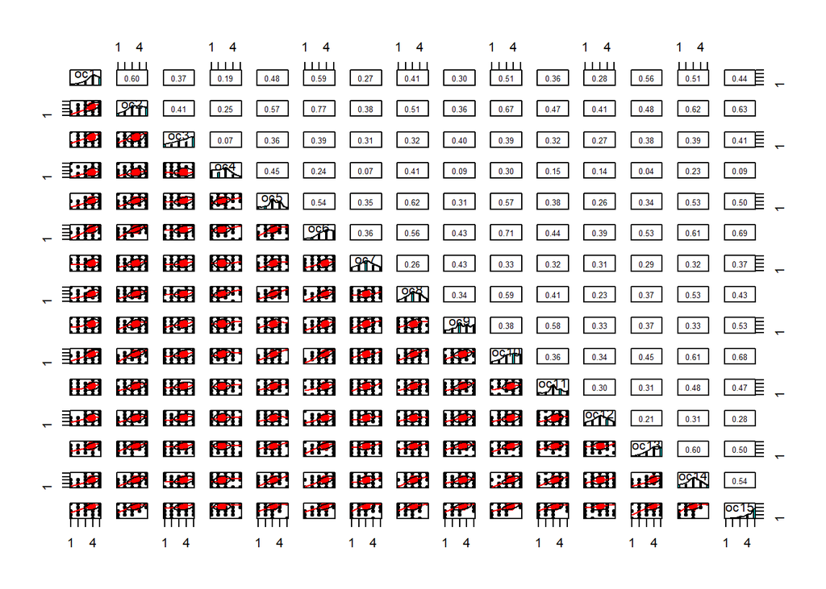

```r
pairs.panels(OC)
```

Next is a simple correlation matrix, as you might get in any other old-school package.

```r
lowerCor(OC)
```

```
##      oc1  oc2  oc3  oc4  oc5  oc6  oc7  oc8  oc9  oc10 oc11
## oc1  1.00
## oc2  0.60 1.00
## oc3  0.37 0.41 1.00
## oc4  0.19 0.25 0.07 1.00
## oc5  0.48 0.57 0.36 0.45 1.00
## oc6  0.59 0.77 0.39 0.24 0.54 1.00
## oc7  0.27 0.38 0.31 0.07 0.35 0.36 1.00
## oc8  0.41 0.51 0.32 0.41 0.62 0.56 0.26 1.00
## oc9  0.30 0.36 0.40 0.09 0.31 0.43 0.43 0.34 1.00
## oc10 0.51 0.67 0.39 0.30 0.57 0.71 0.33 0.59 0.38 1.00
## oc11 0.36 0.47 0.32 0.15 0.38 0.44 0.32 0.41 0.58 0.36 1.00
## oc12 0.28 0.41 0.27 0.14 0.26 0.39 0.31 0.23 0.33 0.34 0.30
## oc13 0.56 0.48 0.38 0.04 0.34 0.53 0.29 0.37 0.37 0.45 0.31
## oc14 0.51 0.62 0.39 0.23 0.53 0.61 0.32 0.53 0.33 0.61 0.48
## oc15 0.44 0.63 0.41 0.09 0.50 0.69 0.37 0.43 0.53 0.68 0.47
##      oc12 oc13 oc14 oc15
## oc12 1.00
## oc13 0.21 1.00
## oc14 0.31 0.60 1.00
## oc15 0.28 0.50 0.54 1.00
```

Next is a ‘heatmap’. The size of the correlation is represented by the colour of the square and the font size of each number. It’s a very cool way to get a visual of the data.

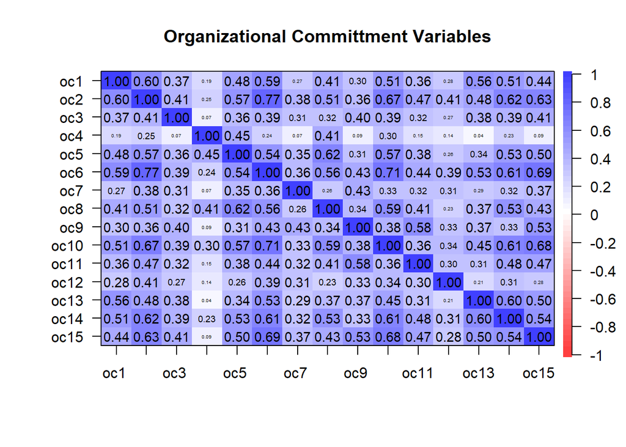

```r
corPlot(OC, numbers=TRUE, main="Organizational Committment Variables")
```

What Mowday et al (1974) do next is calculate coefficient alpha for the item bank, which is simple in R:

```r
alpha(OC)
```

```
##
## Reliability analysis
## Call: alpha(x = OC)
##
##   raw_alpha std.alpha G6(smc) average_r S/N   ase mean   sd median_r
##       0.91      0.91    0.93       0.4  10 0.011  3.4 0.75     0.39
##
##     95% confidence boundaries
##          lower alpha upper
## Feldt     0.88  0.91  0.93
## Duhachek  0.89  0.91  0.93
##
##  Reliability if an item is dropped:
##      raw_alpha std.alpha G6(smc) average_r  S/N alpha se var.r med.r
## oc1       0.90      0.90    0.92      0.40  9.3    0.012 0.023  0.38
## oc2       0.89      0.90    0.91      0.39  8.8    0.013 0.021  0.37
## oc3       0.91      0.91    0.92      0.41  9.8    0.012 0.024  0.41
## oc4       0.91      0.91    0.93      0.43 10.8    0.011 0.016  0.41
## oc5       0.90      0.90    0.92      0.40  9.2    0.012 0.024  0.38
## oc6       0.89      0.90    0.91      0.38  8.7    0.013 0.020  0.37
## oc7       0.91      0.91    0.92      0.42 10.0    0.012 0.023  0.41
## oc8       0.90      0.90    0.92      0.40  9.3    0.012 0.023  0.38
## oc9       0.90      0.91    0.92      0.41  9.6    0.012 0.024  0.39
## oc10      0.90      0.90    0.91      0.39  8.9    0.013 0.021  0.38
## oc11      0.90      0.91    0.92      0.41  9.5    0.012 0.024  0.39
## oc12      0.91      0.91    0.93      0.42 10.1    0.011 0.023  0.41
## oc13      0.90      0.90    0.92      0.40  9.5    0.012 0.022  0.39
## oc14      0.90      0.90    0.92      0.39  9.0    0.013 0.022  0.38
## oc15      0.90      0.90    0.91      0.39  9.0    0.013 0.021  0.38
##
##  Item statistics
##        n raw.r std.r r.cor r.drop mean   sd
## oc1  140  0.68  0.69  0.66   0.63  3.9 1.03
## oc2  140  0.82  0.82  0.82   0.77  3.5 1.22
## oc3  140  0.60  0.58  0.53   0.51  3.7 1.36
## oc4  140  0.37  0.37  0.31   0.28  2.5 1.17
## oc5  140  0.72  0.73  0.71   0.67  3.1 1.02
## oc6  140  0.83  0.83  0.83   0.79  3.8 1.11
## oc7  140  0.55  0.54  0.49   0.47  3.0 1.18
## oc8  140  0.70  0.70  0.68   0.64  3.2 1.06
```

[output cut: 10 more lines]

```
## oc1  0.04 0.07 0.16 0.43 0.31    0
## oc2  0.08 0.12 0.29 0.25 0.26    0
## oc3  0.10 0.11 0.19 0.21 0.39    0
## oc4  0.28 0.20 0.35 0.12 0.05    0
## oc5  0.09 0.11 0.41 0.31 0.06    0
## oc6  0.05 0.06 0.23 0.34 0.31    0
## oc7  0.12 0.18 0.36 0.21 0.13    0
## oc8  0.07 0.18 0.36 0.29 0.10    0
## oc9  0.09 0.14 0.29 0.24 0.24    0
## oc10 0.07 0.10 0.26 0.29 0.28    0
## oc11 0.09 0.11 0.41 0.24 0.16    0
## oc12 0.12 0.16 0.36 0.23 0.12    0
## oc13 0.03 0.08 0.19 0.36 0.34    0
## oc14 0.12 0.15 0.41 0.24 0.09    0
## oc15 0.01 0.06 0.13 0.24 0.56    0
```

Alpha is just a metric for internal consistency, and is problematic to the extent that it simply measures intercorrelation, not what that intercorrelation ‘means’. It is also biased by the number of items - more items always means higher alpha.

So, large item banks like this which are moderately intercorrelated, tend to return high alphas. That’s in part at least, why you see lots of psychological tests from this period consist of many items. This high alpha does not mean there are not multiple factors possible.

Unfortunately, this is where the original Mowday article stops…but we can go further…

## Doing Factor Analysis

We can now look at some statistical metrics to see whether the data are suitable for factor analysis:

```r
KMO(OC)
```

```
## Kaiser-Meyer-Olkin factor adequacy
## Call: KMO(r = OC)
## Overall MSA =  0.91
## MSA for each item =
##  oc1  oc2  oc3  oc4  oc5  oc6  oc7  oc8  oc9 oc10 oc11 oc12 oc13 oc14 oc15
## 0.93 0.93 0.96 0.78 0.91 0.93 0.93 0.92 0.84 0.92 0.87 0.93 0.88 0.92 0.90
```

The Kaiser-Meyer-Olkin (KMO) test is a standard was to assess the suitability of a data set for factor analysis. You are looking for a KMO value of 0.6 or more. Here it is 0.91, so we are good

```r
cortest.bartlett(OC)
```

```
## $chisq
## [1] 1049.199
##
## $p.value
## [1] 1.728165e-155
##
## $df
## [1] 105
```

The Bartlett test is another one we can use. Here you are looking for a p-value <0.05

Ours certainly is that (note the scientific notation)

The next step now depends on a few things. You may have an idea of how many factors underlies the data, or you may not. Technically, we are doing ‘exploratory’ factor analysis, so we don’t have an idea of how many factors there are (indeed, the original authors didn’t even consider this…)

If you do not have *a priori* expectations, you can go one of two ways.

1. Pure exploratory - in SPSS for example, you just run the model, and see what happens…
2. In more recent times, there are some analyses we can do to get some indications, which are easily done on R

First, the Empirical Kaiser Criterion, which is a modification of the old-school Kaiser Criterion, designed to correct for the variables / sample size ratio and the prior eigenvalues observed.

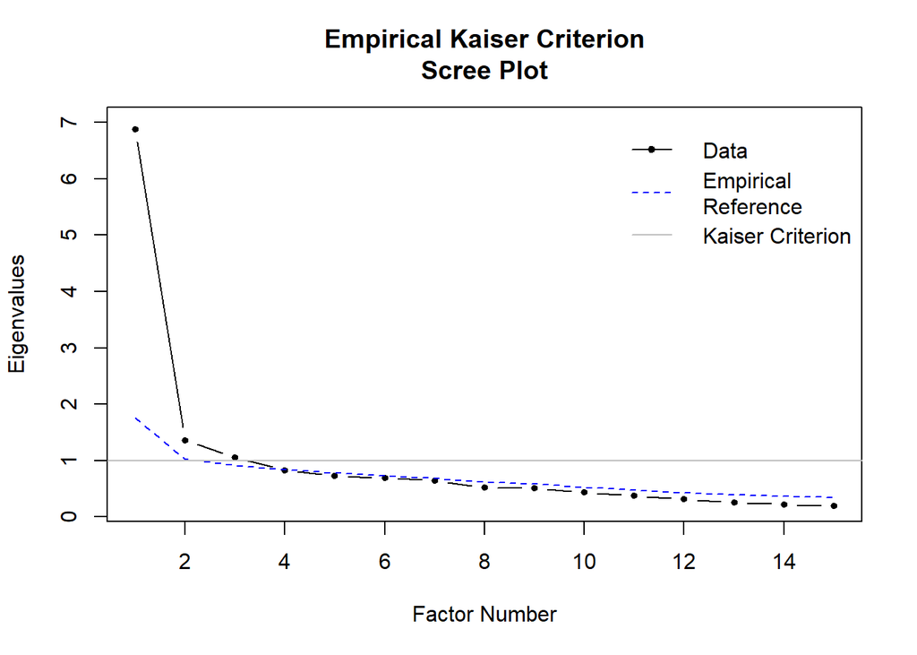

```
##
##  Empirical Kaiser Criterion suggests 3 factors.
##  Traditional Kaiser Criterion suggests 3 factors.
##
##    Sample   Ref
## 1   6.889 1.762
## 2   1.355 1.021
## 3   1.056 0.916
## 4   0.826 0.837
## 5   0.725 0.781
## 6   0.689 0.731
## 7   0.646 0.677
## 8   0.518 0.620
## 9   0.508 0.578
## 10  0.435 0.525
## 11  0.374 0.477
## 12  0.312 0.431
## 13  0.257 0.392
## 14  0.217 0.362
## 15  0.194 0.341
```

```r
efa.ekc(data = OC, sample.cov = NULL, sample.nobs = NULL,
  missing = "default", ordered = NULL, plot = TRUE)
```

Next, the parallel test, which does some simulations to see what the best description of your data is:

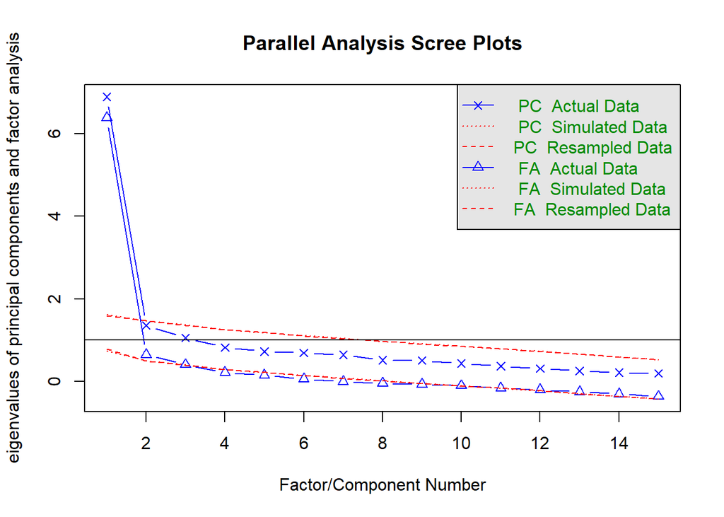

```
## Parallel analysis suggests that the number of factors =  2  and the number of components =  1
```

```r
fa.parallel(OC)
```

This suggests two factors…

Finally, we could use the ‘very simple structure’ method:

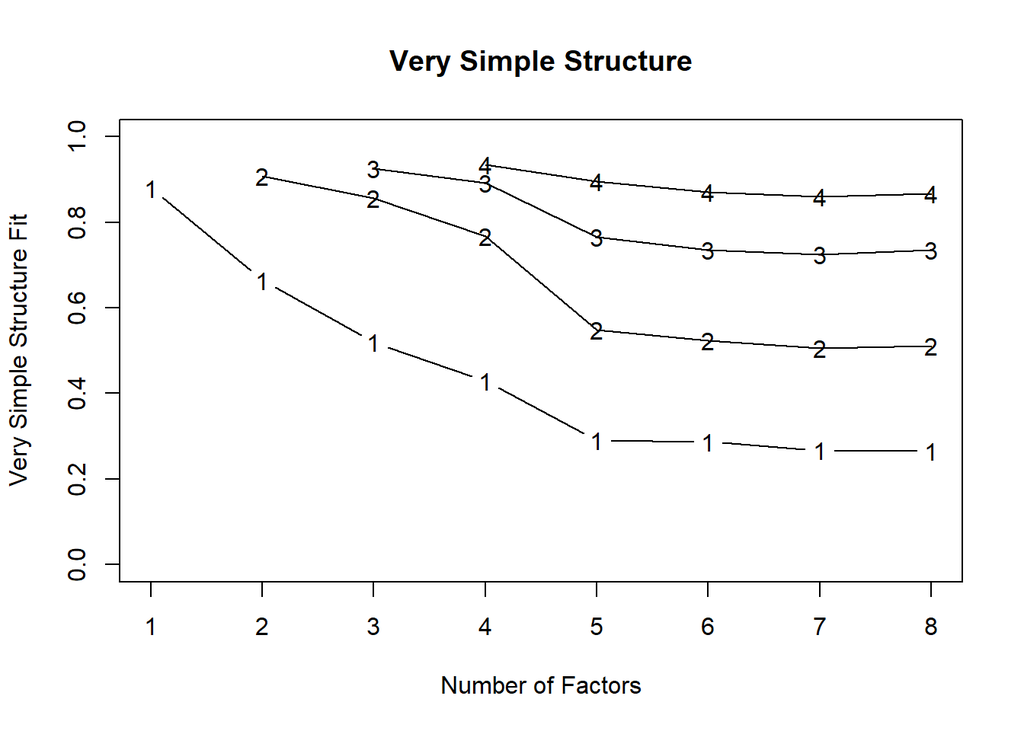

```
##
## Very Simple Structure
## Call: vss(x = OC)
## VSS complexity 1 achieves a maximimum of 0.88  with  1  factors
## VSS complexity 2 achieves a maximimum of 0.91  with  2  factors
##
## The Velicer MAP achieves a minimum of 0.02  with  1  factors
## BIC achieves a minimum of  -253.31  with  1  factors
## Sample Size adjusted BIC achieves a minimum of  -36.33  with  5  factors
##
## Statistics by number of factors
##   vss1 vss2   map dof chisq    prob sqresid  fit RMSEA  BIC SABIC complex
## 1 0.88 0.00 0.022  90 191.4 2.7e-09     6.5 0.88 0.089 -253  31.4     1.0
## 2 0.67 0.91 0.026  76 136.6 2.5e-05     4.9 0.91 0.075 -239   1.5     1.4
## 3 0.52 0.86 0.030  63  86.9 2.5e-02     3.9 0.93 0.052 -224 -25.1     1.8
## 4 0.43 0.77 0.040  51  56.2 2.9e-01     3.5 0.93 0.026 -196 -34.4     2.1
## 5 0.29 0.55 0.054  40  34.8 7.0e-01     3.1 0.94 0.000 -163 -36.3     2.5
## 6 0.29 0.52 0.072  30  21.5 8.7e-01     2.7 0.95 0.000 -127 -31.8     2.5
## 7 0.27 0.51 0.096  21  16.1 7.6e-01     2.5 0.95 0.000  -88 -21.2     2.5
## 8 0.27 0.51 0.120  13   3.8 9.9e-01     2.3 0.96 0.000  -60 -19.3     2.7
##   eChisq   SRMR eCRMS eBIC
## 1  144.7 0.0702 0.076 -300
## 2   73.6 0.0500 0.059 -302
## 3   34.2 0.0341 0.044 -277
## 4   20.9 0.0267 0.038 -231
## 5   11.6 0.0198 0.032 -186
## 6    6.3 0.0146 0.027 -142
## 7    4.4 0.0123 0.027  -99
## 8    1.2 0.0063 0.018  -63
```

```r
vss(OC)
```

It is admittedly challenging to interpret this, and also in conjunction with the parallel results as well. My guess is that the right structure is somewhere between 1 (what the original authors assumed) and 3 (what the EKC and also my Ph.D. analysis using the old-school KC found) factors.

What I would do here is probably test models for all 3 and see which one made most sense, so I will do so below.

**One Factor Solution**

```r
fa1<-(fa(OC,1, fm="pa"))
print(fa1)
```

```
## Factor Analysis using method =  pa
## Call: fa(r = OC, nfactors = 1, fm = "pa")
## Standardized loadings (pattern matrix) based upon correlation matrix
##       PA1   h2   u2 com
## oc1  0.67 0.44 0.56   1
## oc2  0.82 0.68 0.32   1
## oc3  0.53 0.28 0.72   1
## oc4  0.30 0.09 0.91   1
## oc5  0.70 0.48 0.52   1
## oc6  0.84 0.71 0.29   1
## oc7  0.48 0.23 0.77   1
## oc8  0.67 0.45 0.55   1
## oc9  0.56 0.32 0.68   1
## oc10 0.79 0.63 0.37   1
## oc11 0.59 0.35 0.65   1
## oc12 0.44 0.19 0.81   1
## oc13 0.62 0.39 0.61   1
## oc14 0.75 0.57 0.43   1
## oc15 0.76 0.57 0.43   1
##
##                 PA1
## SS loadings    6.39
## Proportion Var 0.43
##
## Mean item complexity =  1
## Test of the hypothesis that 1 factor is sufficient.
##
## df null model =  105  with the objective function =  7.88 with Chi Square =  1049.2
## df of  the model are 90  and the objective function was  1.44
##
## The root mean square of the residuals (RMSR) is  0.07
## The df corrected root mean square of the residuals is  0.08
##
## The harmonic n.obs is  140 with the empirical chi square  144.71  with prob <  0.00023
## The total n.obs was  140  with Likelihood Chi Square =  191.45  with prob <  2.7e-09
##
## Tucker Lewis Index of factoring reliability =  0.874
## RMSEA index =  0.089  and the 90 % confidence intervals are  0.072 0.108
## BIC =  -253.3
## Fit based upon off diagonal values = 0.97
## Measures of factor score adequacy
##                                                    PA1
## Correlation of (regression) scores with factors   0.97
## Multiple R square of scores with factors          0.93
## Minimum correlation of possible factor scores     0.87
```

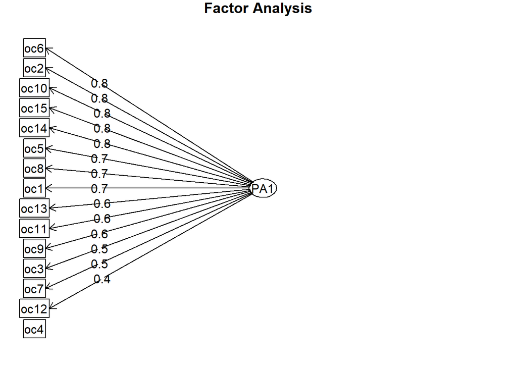

```r
fa.diagram(fa1)
```

**Two Factor Solution**

```r
fa2<-(fa(OC,2, n.obs=143, rotate="oblimin", fm="pa"))
print(fa2)
```

```
## Factor Analysis using method =  pa
## Call: fa(r = OC, nfactors = 2, n.obs = 143, rotate = "oblimin", fm = "pa")
## Standardized loadings (pattern matrix) based upon correlation matrix
##        PA1   PA2   h2   u2 com
## oc1   0.61  0.11 0.44 0.56 1.1
## oc2   0.74  0.15 0.67 0.33 1.1
## oc3   0.60 -0.11 0.31 0.69 1.1
## oc4  -0.01  0.61 0.37 0.63 1.0
## oc5   0.46  0.48 0.62 0.38 2.0
## oc6   0.78  0.13 0.71 0.29 1.1
## oc7   0.56 -0.13 0.27 0.73 1.1
## oc8   0.44  0.46 0.57 0.43 2.0
## oc9   0.72 -0.27 0.43 0.57 1.3
## oc10  0.66  0.25 0.64 0.36 1.3
## oc11  0.65 -0.09 0.38 0.62 1.0
## oc12  0.46 -0.04 0.20 0.80 1.0
## oc13  0.68 -0.10 0.42 0.58 1.0
## oc14  0.68  0.15 0.57 0.43 1.1
## oc15  0.82 -0.10 0.62 0.38 1.0
##
##                        PA1  PA2
## SS loadings           5.97 1.25
## Proportion Var        0.40 0.08
## Cumulative Var        0.40 0.48
## Proportion Explained  0.83 0.17
## Cumulative Proportion 0.83 1.00
##
##  With factor correlations of
##      PA1  PA2
## PA1 1.00 0.41
## PA2 0.41 1.00
##
## Mean item complexity =  1.2
## Test of the hypothesis that 2 factors are sufficient.
##
## df null model =  105  with the objective function =  7.88 with Chi Square =  1049.2
## df of  the model are 76  and the objective function was  1.04
##
## The root mean square of the residuals (RMSR) is  0.05
## The df corrected root mean square of the residuals is  0.06
##
## The harmonic n.obs is  140 with the empirical chi square  73.62  with prob <  0.56
## The total n.obs was  140  with Likelihood Chi Square =  136.73  with prob <  2.4e-05
##
## Tucker Lewis Index of factoring reliability =  0.91
## RMSEA index =  0.075  and the 90 % confidence intervals are  0.055 0.096
## BIC =  -238.83
## Fit based upon off diagonal values = 0.99
## Measures of factor score adequacy
##                                                    PA1  PA2
## Correlation of (regression) scores with factors   0.96 0.84
## Multiple R square of scores with factors          0.93 0.71
## Minimum correlation of possible factor scores     0.86 0.42
```

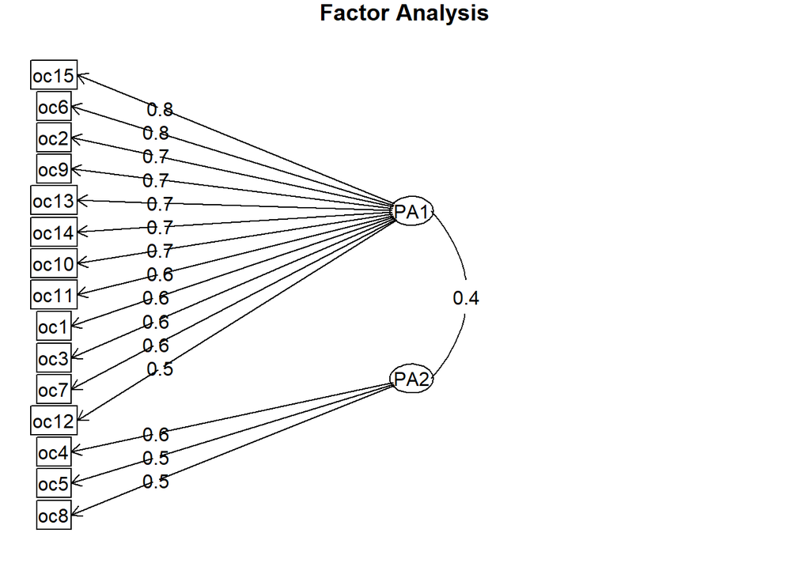

```r
fa.diagram(fa2)
```

**Three Factor Solution**

```r
fa3<-(fa(OC,3, n.obs=143, rotate="oblimin", fm="pa"))
print(fa3)
```

```
## Factor Analysis using method =  pa
## Call: fa(r = OC, nfactors = 3, n.obs = 143, rotate = "oblimin", fm = "pa")
## Standardized loadings (pattern matrix) based upon correlation matrix
##        PA1   PA2   PA3   h2   u2 com
## oc1   0.73 -0.06 -0.01 0.49 0.51 1.0
## oc2   0.79  0.01  0.08 0.70 0.30 1.0
## oc3   0.40  0.24 -0.05 0.31 0.69 1.7
## oc4  -0.07 -0.01  0.72 0.48 0.52 1.0
## oc5   0.39  0.08  0.50 0.63 0.37 2.0
## oc6   0.82  0.03  0.05 0.73 0.27 1.0
## oc7   0.24  0.35  0.00 0.28 0.72 1.7
## oc8   0.37  0.09  0.47 0.58 0.42 2.0
## oc9  -0.04  0.94 -0.01 0.83 0.17 1.0
## oc10  0.70  0.01  0.19 0.65 0.35 1.1
## oc11  0.21  0.49  0.09 0.44 0.56 1.4
## oc12  0.25  0.24  0.05 0.21 0.79 2.1
## oc13  0.78 -0.01 -0.23 0.50 0.50 1.2
## oc14  0.74  0.00  0.06 0.59 0.41 1.0
## oc15  0.65  0.24 -0.07 0.61 0.39 1.3
##
##                        PA1  PA2  PA3
## SS loadings           4.98 1.73 1.30
## Proportion Var        0.33 0.12 0.09
## Cumulative Var        0.33 0.45 0.53
## Proportion Explained  0.62 0.22 0.16
## Cumulative Proportion 0.62 0.84 1.00
##
##  With factor correlations of
##      PA1  PA2  PA3
## PA1 1.00 0.56 0.44
## PA2 0.56 1.00 0.19
## PA3 0.44 0.19 1.00
##
## Mean item complexity =  1.4
## Test of the hypothesis that 3 factors are sufficient.
##
## df null model =  105  with the objective function =  7.88 with Chi Square =  1049.2
## df of  the model are 63  and the objective function was  0.66
##
## The root mean square of the residuals (RMSR) is  0.03
## The df corrected root mean square of the residuals is  0.04
##
## The harmonic n.obs is  140 with the empirical chi square  34.22  with prob <  1
## The total n.obs was  140  with Likelihood Chi Square =  87  with prob <  0.024
##
## Tucker Lewis Index of factoring reliability =  0.957
## RMSEA index =  0.052  and the 90 % confidence intervals are  0.02 0.078
## BIC =  -224.32
## Fit based upon off diagonal values = 0.99
## Measures of factor score adequacy
##                                                    PA1  PA2  PA3
## Correlation of (regression) scores with factors   0.96 0.93 0.85
## Multiple R square of scores with factors          0.93 0.87 0.73
## Minimum correlation of possible factor scores     0.85 0.75 0.46
```

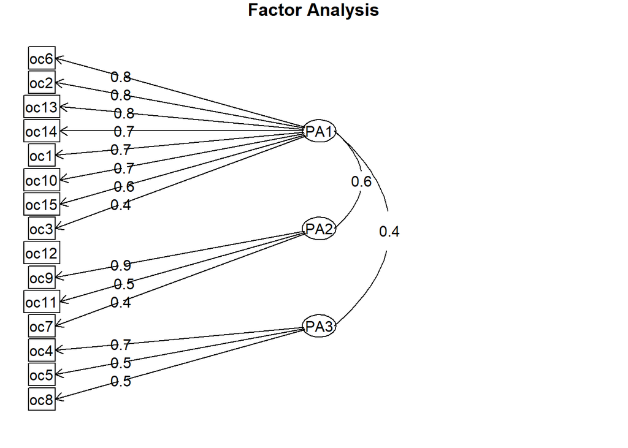

```r
fa.diagram(fa3)
```